# temp_final-analysis_JAN2025

### Interpret and visualize model results

```r
#to interpret model results

##CTmax
get_model_data(model.4b,type="pred", terms = c("sex.2"))
```

```
## # Predicted values of CTmax.C
##
## sex.2 | Predicted |       95% CI | group_col
## --------------------------------------------
##     1 |     35.59 | 34.78, 36.40 |         1
##     2 |     35.16 | 34.41, 35.92 |         1
##     3 |     35.17 | 34.62, 35.72 |         1
```

```r
##CTmin
get_model_data(model.5b,type="pred", terms = c("sex.2"))
```

```
## # Predicted values of CTmin.C
##
## sex.2 | Predicted |      95% CI | group_col
## -------------------------------------------
##     1 |      9.81 | 9.29, 10.32 |         1
##     2 |     10.14 | 9.66, 10.62 |         1
##     3 |      9.73 | 9.38, 10.09 |         1
```

```r
##Tot temp
get_model_data(model.6b,type="pred", terms = c("sex.2"))
```

```
## # Predicted values of T.tot
##
## sex.2 | Predicted |       95% CI | group_col
## --------------------------------------------
##     1 |     25.78 | 24.85, 26.72 |         1
##     2 |     25.02 | 24.15, 25.90 |         1
##     3 |     25.44 | 24.80, 26.08 |         1
```

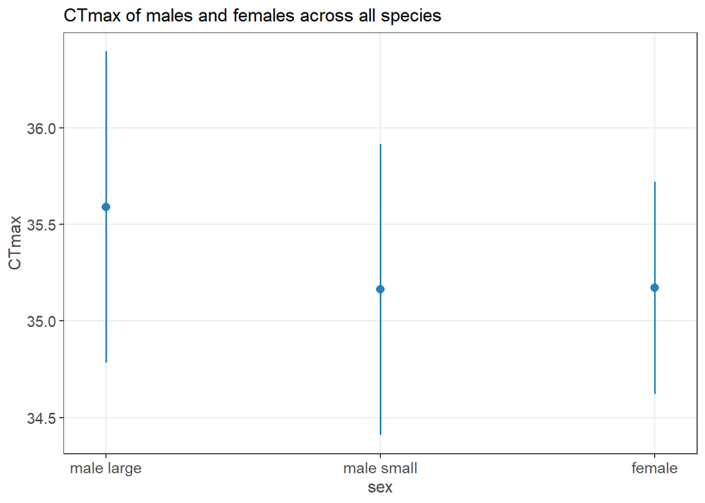

```r
#plot results

##CTmax
set_theme(base = theme_bw(), panel.minor.gridcol = 'white')

##using the type="pred" parameter allows us to visualize how specific terms affect our outcome variable. This will create a graph with sex/mating categories on the x, and CTmax on the y.
CTMAX_results_SW <- plot_model(model.4b,
             type = "pred",
             terms = c("sex.2"),
             colors=c("#2980b9", "#16a085", "#f39c12"),
             axis.title = c("sex", "CTmax"),
             legend.title = c("sex"), title = "CTmax of males and females across all species")

CTMAX_results_SW
```

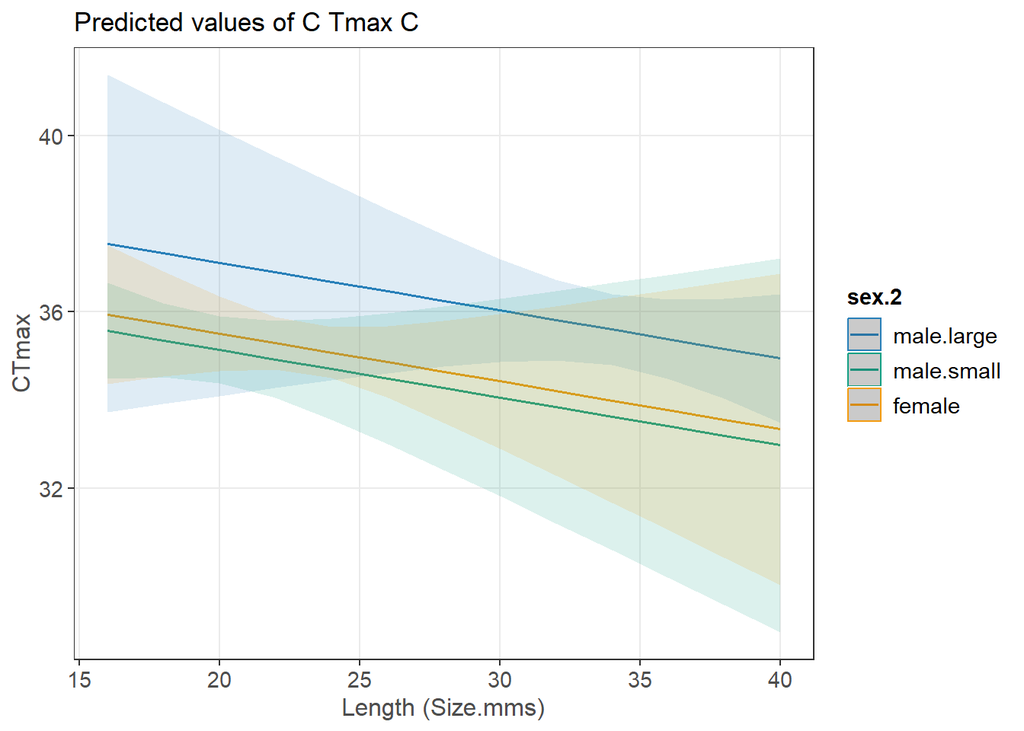

```r
#now lets also include size. This will create a figure with size as the x-axis, ctmax as the y, and three predictor lines for the sexes/mating styles

CTMAX_results2_SW <- plot_model(model.4a,
             type = "pred",
             terms = c("Size.mm", "sex.2"),
             colors=c("#2980b9", "#16a085", "#f39c12"),
             axis.title = c("Length (Size.mms)", "CTmax"),
             legend.title = c("sex.2"))

CTMAX_results2_SW
```

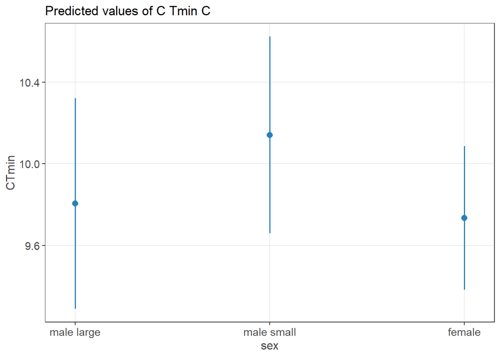

```r
##CTmin

set_theme(base = theme_bw(), panel.minor.gridcol = 'white')

##using the type="pred" parameter allows us to visualize how specific terms affect our outcome variable. This will create a graph with sex/mating categories on the x, and CTmax on the y.
CTMIN_results_SW <- plot_model(model.5b,
             type = "pred",
             terms = c("sex.2"),
             colors=c("#2980b9", "#16a085", "#f39c12"),
             axis.title = c("sex", "CTmin"),
             legend.title = c("sex"))

CTMIN_results_SW
```

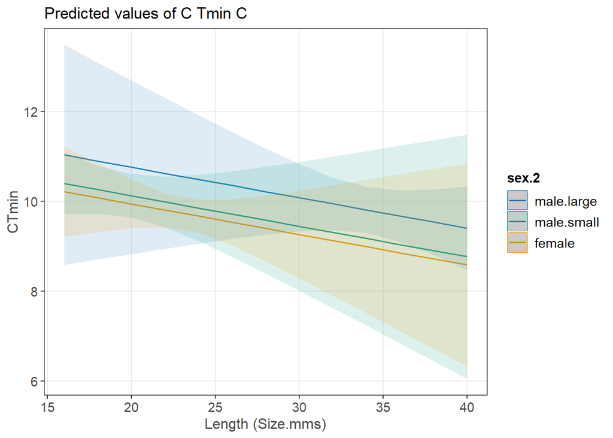

```r
#now lets also include size. This will create a figure with size as the x-axis, ctmax as the y, and three predictor lines for the sexes/mating styles

CTMIN_results2_SW <- plot_model(model.5a,
             type = "pred",
             terms = c("Size.mm", "sex.2"),
             colors=c("#2980b9", "#16a085", "#f39c12"),
             axis.title = c("Length (Size.mms)", "CTmin"),
             legend.title = c("sex.2"))

CTMIN_results2_SW
```

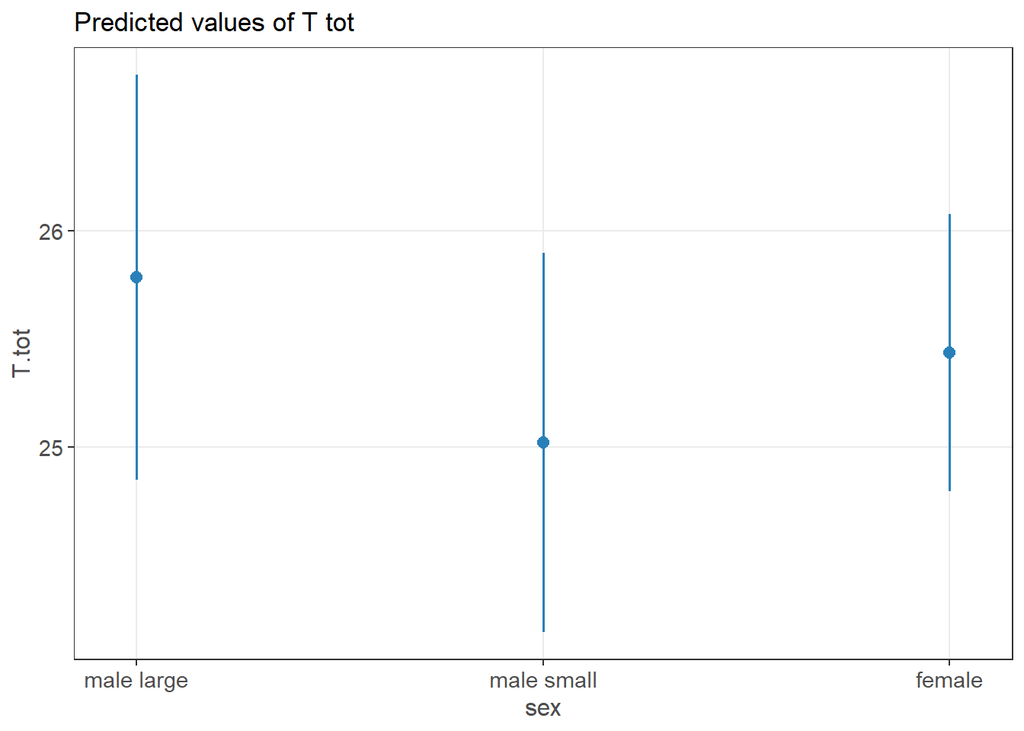

```r
##Tot temp

set_theme(base = theme_bw(), panel.minor.gridcol = 'white')

##using the type="pred" parameter allows us to visualize how specific terms affect our outcome variable. This will create a graph with sex/mating categories on the x, and CTmax on the y.
TTOT_results_SW <- plot_model(model.6b,
             type = "pred",
             terms = c("sex.2"),
             colors=c("#2980b9", "#16a085", "#f39c12"),
             axis.title = c("sex", "T.tot"),
             legend.title = c("sex"))

TTOT_results_SW
```

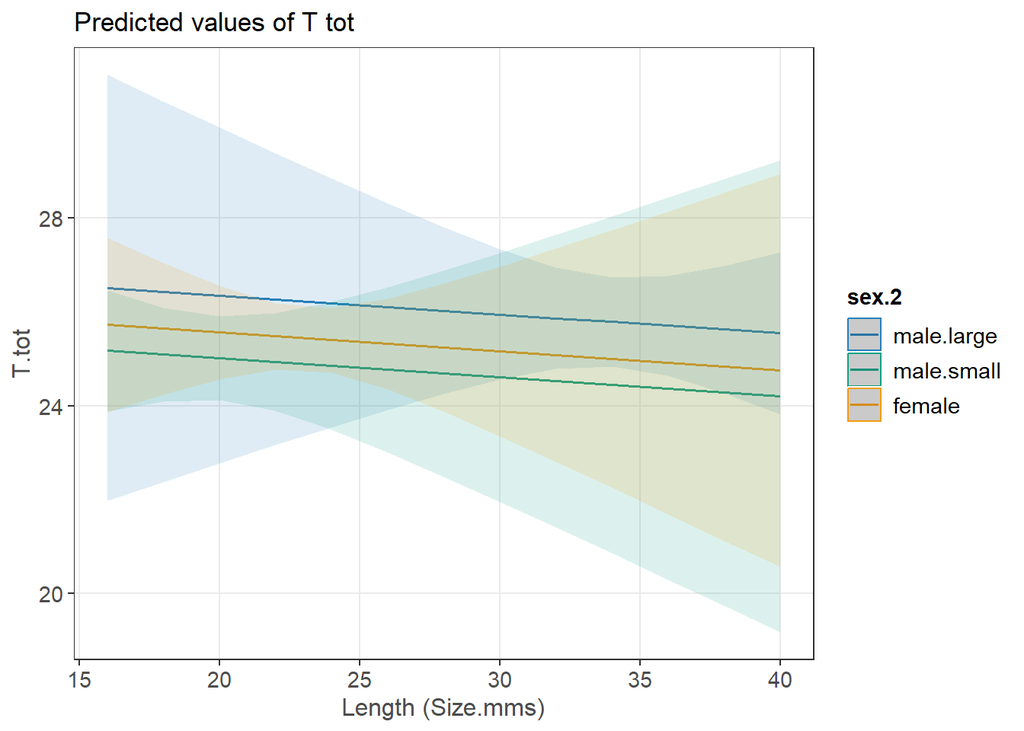

```r
#now lets also include size. This will create a figure with size as the x-axis, ctmax as the y, and three predictor lines for the sexes/mating styles

TTOT_results2_SW <- plot_model(model.6a,
             type = "pred",
             terms = c("Size.mm", "sex.2"),
             colors=c("#2980b9", "#16a085", "#f39c12"),
             axis.title = c("Length (Size.mms)", "T.tot"),
             legend.title = c("sex.2"))

TTOT_results2_SW
```

### Question 2 results

CTMAX - no significant difference in either male type (coercise or courting) and females. - mean around 35.15 deg C

CTMIN - also no sig difference between female and male swordtails for the min temp they can withstand - mean around 9.78 deg C

TTOT - again no sig difference between female and male swordtails for the total temp - mean of 25.4

# Visualizations

This will be a section to create and save all of your figures. Some may be repeats of what you’ve done above, but it’s nice to have it all in one spot. To save a figure as a jpeg/pdf/png etc, use the code below. This will matter most when we figure out what the publisher wants your figures saved as.

< save_plot(filename=image_name.jpg, fig=figure_name, width=30, height=19) > - replace .jpg with .pdf, .png etc to change file format - adjust width and height numbers as needed/wanted

## Summary stats

Here we’ll just have some basic summary stats plots. These may be included in supplementary material, but chances are, they’re not informative enough for the main text.

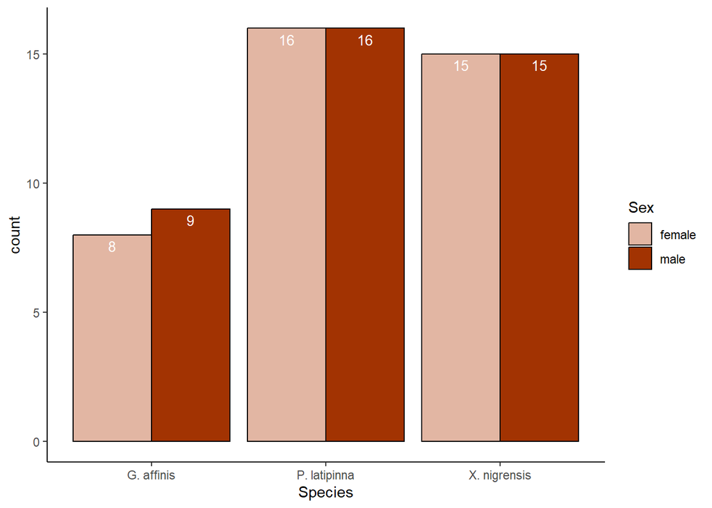

```r
#male= #A23302
#female= #E2B6A3
#sailfin/sailfin.male= #3E1C58
#sailfin.female=#A1BDCE
#swordtail/swordtail.male.lg= #004D40
#swordtail.male.sm= #208D98
#swordtail.female= #DAA912
#mosquitofish/mosquito.male= #81822F
#mosquito.female= #DAD1EC

sexINspecies<- ggplot(data=rawTempData, aes(x=Species, fill=Sex)) + geom_bar(color= "black", position=position_dodge())+ theme_classic() + scale_fill_manual(values = c("#E2B6A3", "#A23302")) + geom_text(aes(label=..count..), stat="count", position = position_dodge(width = 0.9), vjust=1.5, color="white", size=3.5)

sexINspecies
```

## Model visualizations

Copy the visualizations of the final chosen models you performed above.

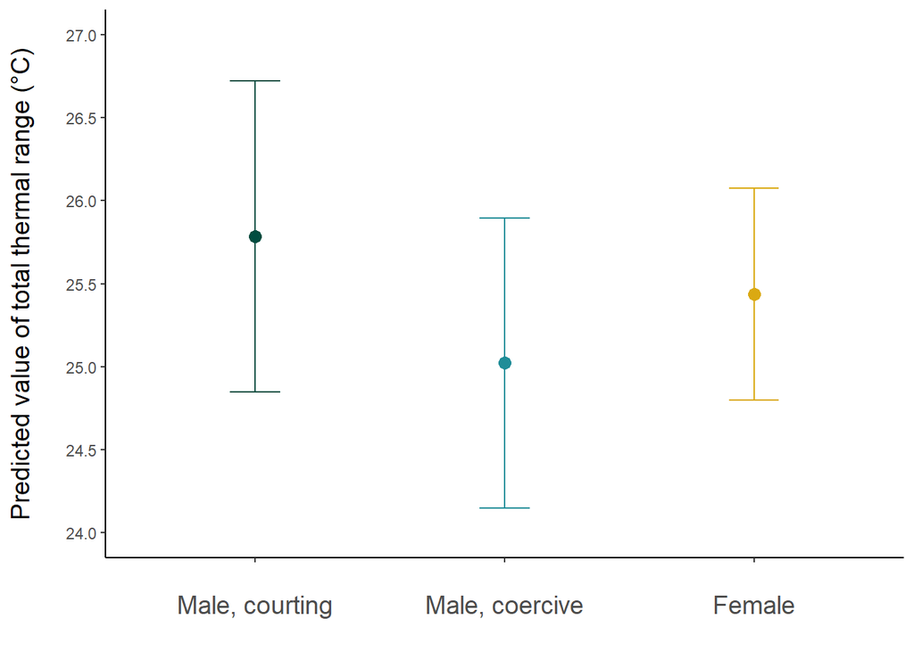

```r
library(ggeffects)

#Question1
##CTMax

###Table
##CTmax_table <- tab_model(model_name, show.reflvl=T, show.intercept=F, p.style="numeric_stars")
##CTmax_table

##CTmin


###Table



##Tottemp


###Table



########################

#Question2

##CTmax




###Table



##CTmin



###Table



########## Tottemp ##########

##### no size

predictions.6b <- ggpredict(model.6b, terms= "sex.2")

SW_TT_6b <- ggplot(predictions.6b, aes(x = x, y = predicted, color = x)) +
  geom_point(size = 3) +
  geom_errorbar(aes(ymin = conf.low, ymax = conf.high), width = 0.2) +
  scale_color_manual(
    values = c("male.large" = "#004D40", "male.small" = "#208D98", "female" = "#DAA912")) +
    scale_x_discrete(
      labels = c("male.large"= "\nMale, courting", "male.small" = "\nMale, coercive", "female"="\nFemale")) +
    scale_y_continuous(
      limits = c(24, 27),
      breaks = seq(24,27, by=0.5)
    ) +
  labs(x = " ", y = "Predicted value of total thermal range (\u00B0C)\n"
       ) +
  theme_classic() +
  theme(legend.position = "none",
        axis.text.x = element_text(size = 14),
        axis.title.y = element_text(size = 14))

SW_TT_6b
```

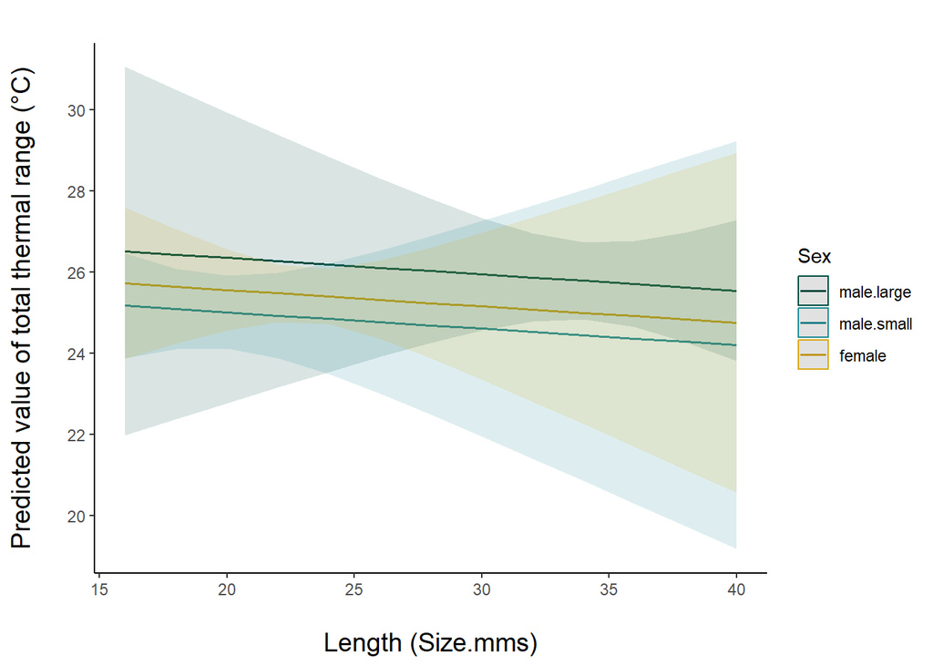

```r
#save_plot(filename=swordtail_total-temp.jpg, fig=SW_TT_6b, width=30, height=19)
  ## have not tested this out in terms of width and height, may need to adjust

##### with size
  # not sure why, but can't get the above ggplot to work for the size variable (creates a graph but no confidence intervals). Since plot_model creates a ggplot as an output, we'll stick with plot_model for the model graphs using size, and then modify to make it prettier using ggplot commands.

SW_TT_6a <- plot_model(model.6a,
             type = "pred",
             terms = c("Size.mm", "sex.2"),
             colors=c("#004D40", "#208D98", "#DAA912"),
             axis.title = c("\nLength (Size.mms)", "Predicted value of total thermal range (\u00B0C)\n"),
             legend.title = c("Sex"))

SW_TT_6a <- SW_TT_6a +
  theme_classic()+
  scale_y_continuous(
      breaks = seq(20,30, by=2)
    ) +
  theme(
        axis.title.x = element_text(size = 14),
        axis.title.y = element_text(size = 14)) +
  ggtitle(" ")
SW_TT_6a
```

```r
#save_plot(filename=swordtail_total-temp_size.jpg, fig=SW_TT_6a, width=30, height=19)
  ## have not tested this out in terms of width and height, may need to adjust


###Table
```

## Species visualizations

### Simple

Here we’ll have the box plots you created beforehand, just as a quick visualization of the sexes within each species.

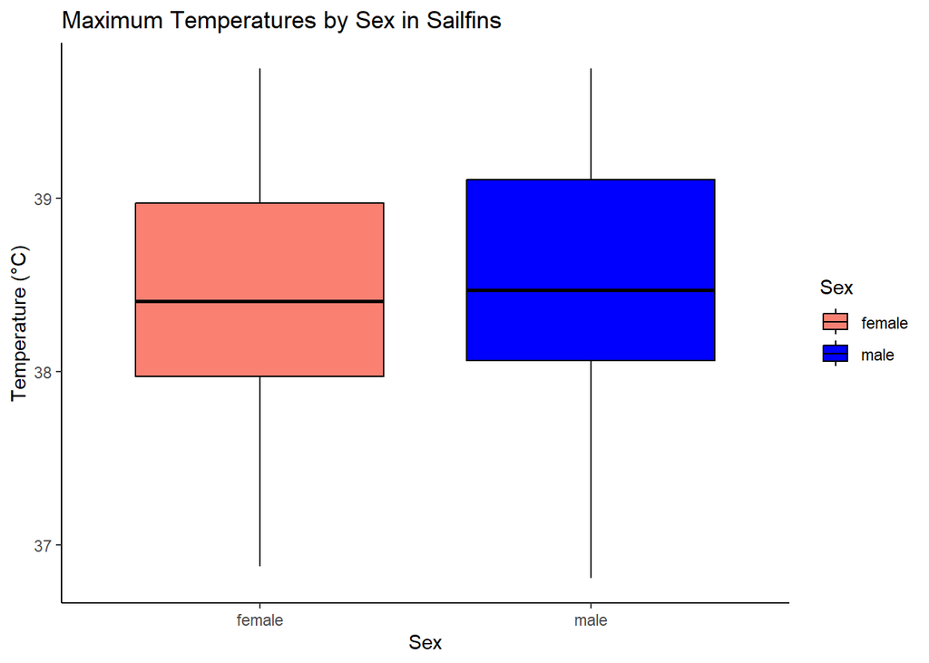

```r
#species data sets
sailfin_1 <- rawTempData[rawTempData$Species =="P. latipinna",]
mosquito_1 <- rawTempData[rawTempData$Species =="G. affinis",]



#male v female max temp in sailfin
sailfin_boxplot1 <- ggplot(data = sailfin_1,
                           aes(x = Sex,
                               y = CTmax.C,
                               fill = Sex)) +
  geom_boxplot(color = "black") +
  labs(
    title = "Maximum Temperatures by Sex in Sailfins",
    x = "Sex",
    y = "Temperature (°C)"
  ) +
  theme_classic() +
  scale_fill_manual(values = c("salmon", "blue"))


print(sailfin_boxplot1)
```

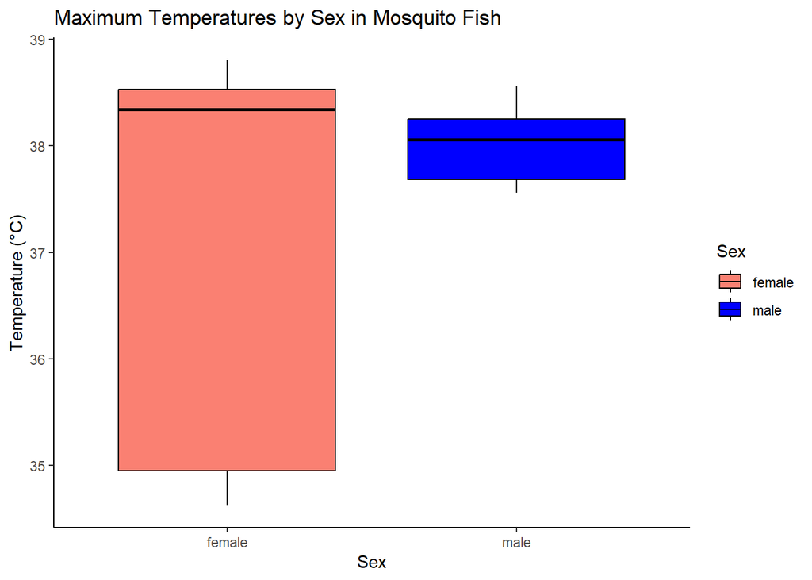

```r
#male v female max temp in mosquitofish
mosquito_boxplot1 <- ggplot(data = mosquito_1,
                           aes(x = Sex,
                               y = CTmax.C,
                               fill = Sex)) +
  geom_boxplot(color = "black") +
  labs(
    title = "Maximum Temperatures by Sex in Mosquito Fish",
    x = "Sex",
    y = "Temperature (°C)"
  ) +
  theme_classic() +
  scale_fill_manual(values = c("salmon", "blue"))

print(mosquito_boxplot1)
```

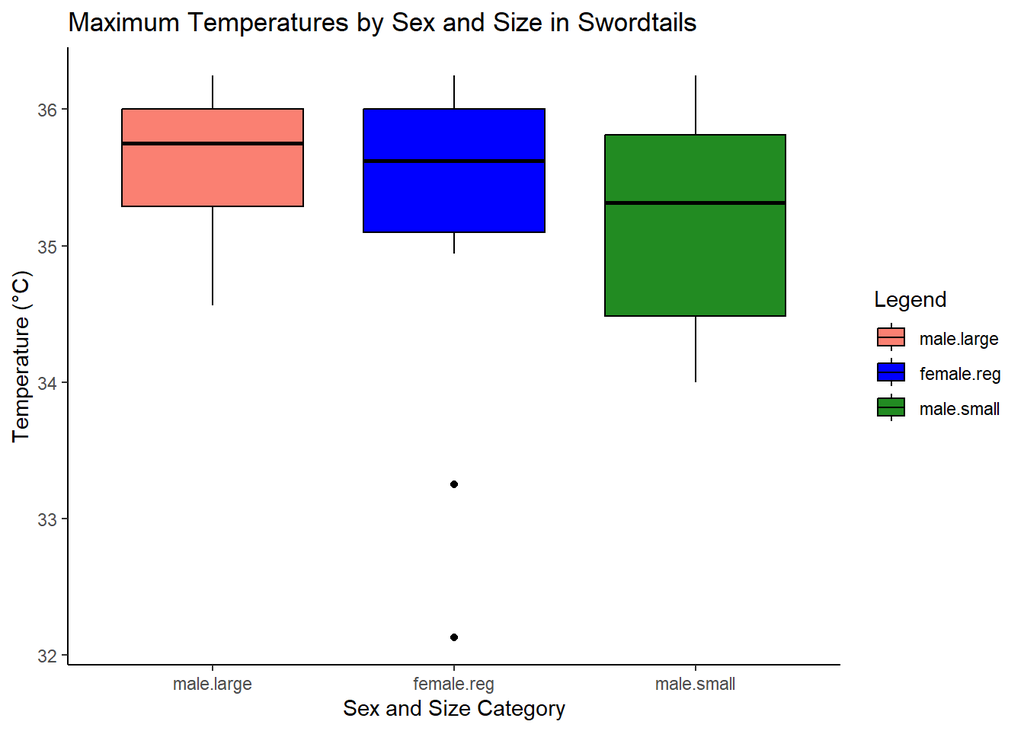

```r
#male v female max temp in swordtail (might want to either create another graph distinguishing between small and large males or just add size category as a shape difference)
swordtail_boxplot4 <- ggplot(data = swordtail_1,
                             aes(x = interaction(Sex, Size.cat),
                                 y = CTmax.C,
                                 fill = interaction(Sex, Size.cat))) +
  geom_boxplot(color = "black") +
  labs(
    title = "Maximum Temperatures by Sex and Size in Swordtails",
    x = "Sex and Size Category",
    y = "Temperature (°C)",
    fill = "Legend"
  ) +
  theme_classic() +
  scale_fill_manual(values = c("salmon", "blue", "forestgreen"))

print(swordtail_boxplot4)
```

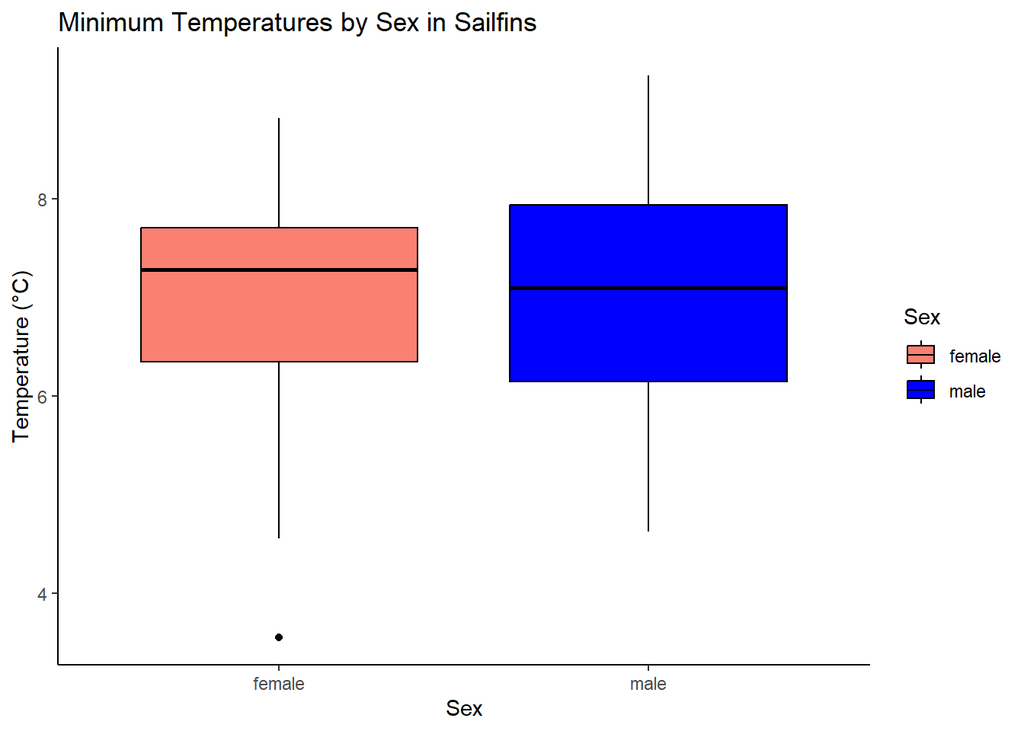

```r
#male v female min temp in sailfin
sailfin_boxplot2 <- ggplot(data = sailfin_1,
                           aes(x = Sex,
                               y = CTmin.C,
                               fill = Sex)) +
  geom_boxplot(color = "black") +
  labs(
    title = "Minimum Temperatures by Sex in Sailfins",
    x = "Sex",
    y = "Temperature (°C)"
  ) +
  theme_classic() +
  scale_fill_manual(values = c("salmon", "blue"))

print(sailfin_boxplot2)
```

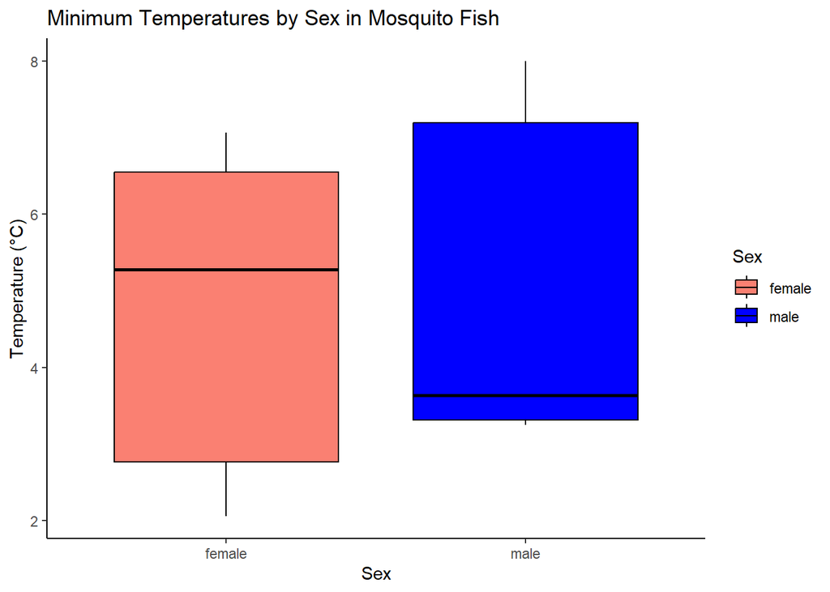

```r
#male v female min temp in mosquitofish
mosquito_boxplot2 <- ggplot(data = mosquito_1,
                           aes(x = Sex,
                               y = CTmin.C,
                               fill = Sex)) +
  geom_boxplot(color = "black") +
  labs(
    title = "Minimum Temperatures by Sex in Mosquito Fish",
    x = "Sex",
    y = "Temperature (°C)"
  ) +
  theme_classic() +
  scale_fill_manual(values = c("salmon", "blue"))

print(mosquito_boxplot2)
```

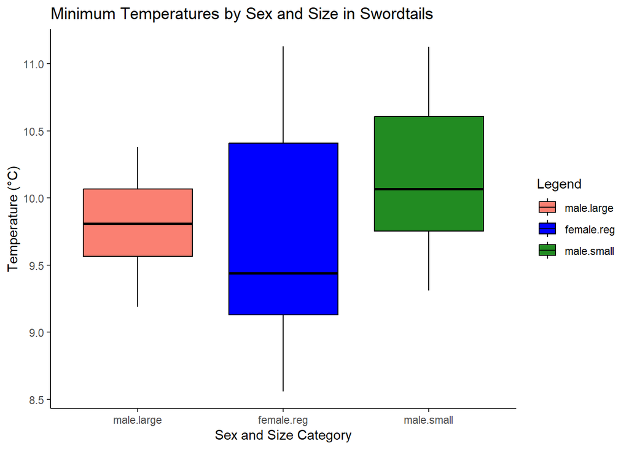

```r
#male v female min temp in swordtail (might want to either create another graph distinguishing between small and large males or just add size category as a shape difference)
swordtail_boxplot5 <- ggplot(data = swordtail_1,
                             aes(x = interaction(Sex, Size.cat),
                                 y = CTmin.C,
                                 fill = interaction(Sex, Size.cat))) +
  geom_boxplot(color = "black") +
  labs(
    title = "Minimum Temperatures by Sex and Size in Swordtails",
    x = "Sex and Size Category",
    y = "Temperature (°C)",
    fill = "Legend"
  ) +
  theme_classic() +
  scale_fill_manual(values = c("salmon", "blue", "forestgreen"))

print(swordtail_boxplot5)
```

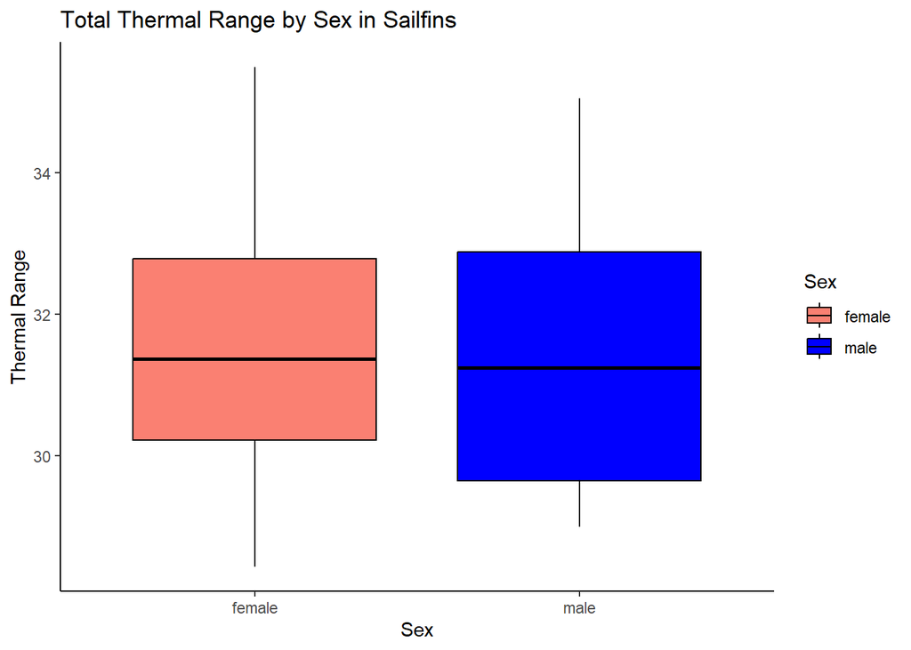

```r
#male v female tot temp in sailfin
sailfin_boxplot3 <- ggplot(data = sailfin_1,
                           aes(x = Sex,
                               y = T.tot,
                               fill = Sex)) +
  geom_boxplot(color = "black") +
  labs(
    title = "Total Thermal Range by Sex in Sailfins",
    x = "Sex",
    y = "Thermal Range"
  ) +
  theme_classic() +
  scale_fill_manual(values = c("salmon", "blue"))

print(sailfin_boxplot3)
```

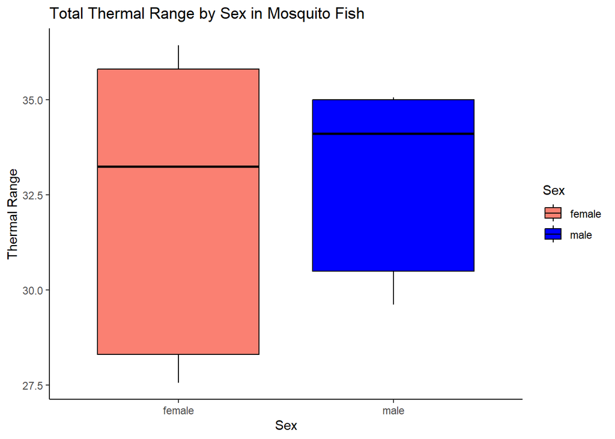

```r
#male v female tot temp in mosquitofish
mosquito_boxplot3 <- ggplot(data = mosquito_1,
                           aes(x = Sex,
                               y = T.tot,
                               fill = Sex)) +
  geom_boxplot(color = "black") +
  labs(
    title = "Total Thermal Range by Sex in Mosquito Fish",
    x = "Sex",
    y = "Thermal Range"
  ) +
  theme_classic() +
  scale_fill_manual(values = c("salmon", "blue"))

print(mosquito_boxplot3)
```

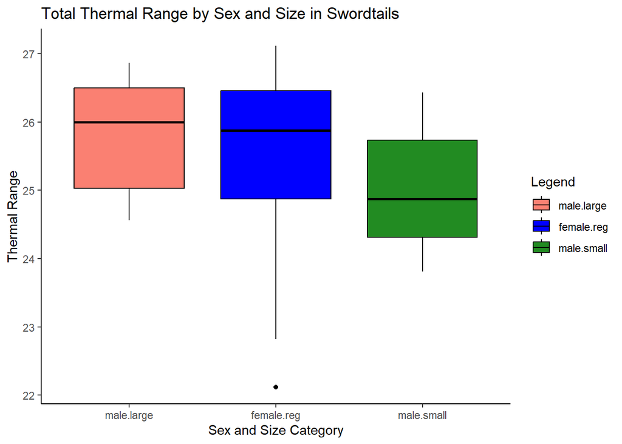

```r
#male v female tot temp in swordtail (might want to either create another graph distinguishing between small and large males or just add size category as a shape difference)
swordtail_boxplot6 <- ggplot(data = swordtail_1,
                             aes(x = interaction(Sex, Size.cat),
                                 y = T.tot,
                                 fill = interaction(Sex, Size.cat))) +
  geom_boxplot(color = "black") +
  labs(
    title = "Total Thermal Range by Sex and Size in Swordtails",
    x = "Sex and Size Category",
    y = "Thermal Range",
    fill = "Legend"
  ) +
  theme_classic() +
  scale_fill_manual(values = c("salmon", "blue", "forestgreen"))

print(swordtail_boxplot6)
```